# **Consequência sobre Alocação de Portfólio**

- **Candidatos** — o que muda em cada versão e como foi montada
- **Essencial** — cota, retorno mensal e métricas
- **Alfa** — cota, retorno mensal e métricas
- **Beta** — cota, retorno mensal e métricas
- **LS** — cota, retorno mensal e métricas
- **LO** — cota, retorno mensal e métricas
- **Choques** — Essencial, alfa e LS nos choques surpresa
- **Choques decompostos** — β da véspera, β surpresa e seleção do LS
- **Sobreposição** — LS contra o LO e o beta do fundo
- **LS contra o LO 100** — dispersão, β e os piores dias do LO
- **LS contra o IBOV** — retorno por faixa do IBOV e convexidade
- **Alocação e Exposição** — peso do LS e do LO no Essencial, net e gross do LS
- **Conclusão**

Voltar ao Menu

### **Candidatos**

Segunda etapa da pesquisa: a primeira (Choques de Mercado) concluiu que o L&S deve trocar a neutralização por vol pela fusão **mvol (2m|12m) + beta_lambda**. Aqui, o que isso faz no portfólio: alfa, beta e Essencial. Todos os modelos nas versões atuais:

| Versão | LS e LO |
| --- | --- |
| `vol` | a produção: neutralização por vol, 42 dias. É a base de comparação |
| `mvol+beta_lambda` | **a decisão**: 50% `mvol 2m\\|12m` (a vol medida em 42 e 247 dias) e 50% `beta_lambda` (notional neutral, pesos pelo beta de 6 meses) |
| `mqvol+beta_lambda` | 50% `mqvol 2m\\|12m` (o quantil 95% de \|r\| no lugar da vol) e 50% `beta_lambda` |
| `vol+beta_lambda` | 50% `vol` e 50% `beta_lambda`: o ganho só de acrescentar a perna notional neutral, sem a janela de 12 meses |
| `beta_lambda` | a `beta_lambda` pura |

**Como foi montado, como será na produção:**

1. Cada versão é um run completo do Factors com o input de 16/11/2026, num clone isolado (output e temp próprios; nada gravado na produção). O `str_preco_reversal` e o `reversal` estão desligados em todas, como na produção a partir de agora; por isso a `vol` daqui não é idêntica à produção de 16/11.
2. **A fusão é a do passo 10 do Factors:** os pesos diários por papel de cada modelo (antes dos triggers) são somados pelos pesos 50/50, e os passos 11 e 12 (triggers de vol, pesos finais e cota com corretagem e aluguel) rodam uma vez, sobre a carteira fundida. Vale para o `ls` (com a camada discricionária) e para o `lo_timing`.
3. O `ls` e o `lo_timing` de cada versão entram no notebook `portfolio` da produção no lugar do `ls new` e do `lo_timing new`; o resto da cadeia (beta Brasil, beta global, cosmos, alfa, Essencial) é o mesmo.
4. O `t vs vol` é o teste de diferença de Sharpe contra a `vol` (mesmo período, mesmos dias).

Voltar ao Menu

Essencial

Through November 13, 2026

[interactive chart not shown]

**vol**

| year | Jan | Feb | Mar | Apr | May | Jun | Jul | Aug | Sep | Oct | Nov | Dec | Year % |
| --- | --- | --- | --- | --- | --- | --- | --- | --- | --- | --- | --- | --- | --- |
| 2026 | 6.1 | 1.0 | -4.0 | -1.4 | -2.7 | 1.2 | 2.4 | 0.9 | 4.8 | -1.7 | -0.1 | – | 6.1 |

**mvol+beta_lambda**

| year | Jan | Feb | Mar | Apr | May | Jun | Jul | Aug | Sep | Oct | Nov | Dec | Year % |
| --- | --- | --- | --- | --- | --- | --- | --- | --- | --- | --- | --- | --- | --- |
| 2026 | 6.2 | 0.5 | -3.3 | -1.6 | -1.5 | 1.4 | 2.1 | 1.3 | 4.7 | 1.6 | 0.2 | – | 11.8 |

**mqvol+beta_lambda**

| year | Jan | Feb | Mar | Apr | May | Jun | Jul | Aug | Sep | Oct | Nov | Dec | Year % |
| --- | --- | --- | --- | --- | --- | --- | --- | --- | --- | --- | --- | --- | --- |
| 2026 | 6.3 | 0.5 | -3.4 | -1.6 | -1.8 | 1.4 | 2.2 | 1.5 | 4.8 | 2.8 | 0.3 | – | 13.4 |

**vol+beta_lambda**

| year | Jan | Feb | Mar | Apr | May | Jun | Jul | Aug | Sep | Oct | Nov | Dec | Year % |
| --- | --- | --- | --- | --- | --- | --- | --- | --- | --- | --- | --- | --- | --- |
| 2026 | 6.2 | 0.6 | -3.3 | -1.6 | -1.9 | 1.4 | 2.2 | 1.2 | 4.9 | 0.3 | 0.1 | – | 10.1 |

**beta_lambda**

| year | Jan | Feb | Mar | Apr | May | Jun | Jul | Aug | Sep | Oct | Nov | Dec | Year % |
| --- | --- | --- | --- | --- | --- | --- | --- | --- | --- | --- | --- | --- | --- |
| 2026 | 6.2 | 0.2 | -2.7 | -1.7 | -0.9 | 1.6 | 1.7 | 1.4 | 4.9 | 2.4 | 0.3 | – | 13.9 |

Essencial | 2008+ até 13/11/2026

|  | sharpe | t vs vol | sharpe 10a | sharpe 5a | cagr % | vol % | max dd % | pior mês % | média quedas % | média altas % | Lula Day % | 2026 % |
| --- | --- | --- | --- | --- | --- | --- | --- | --- | --- | --- | --- | --- |
| vol | 2.12 | – | 2.38 | 1.54 | 36.86 | 12.66 | -9.83 | -8.19 | -2.42 | -0.27 | -6.74 | 6.11 |
| mvol+beta_lambda | 2.21 | 1.35 | 2.46 | 1.72 | 37.60 | 12.46 | -9.77 | -8.20 | -1.60 | -0.45 | -4.78 | 11.84 |
| mqvol+beta_lambda | 2.22 | 1.35 | 2.46 | 1.76 | 37.56 | 12.43 | -9.98 | -8.48 | -1.49 | -0.52 | -3.78 | 13.38 |
| vol+beta_lambda | 2.22 | 1.62 | 2.46 | 1.69 | 37.75 | 12.51 | -9.86 | -8.23 | -1.96 | -0.31 | -5.84 | 10.10 |
| beta_lambda | 2.21 | 0.73 | 2.46 | 1.70 | 37.36 | 12.40 | -10.21 | -8.38 | -1.28 | -0.39 | -4.87 | 13.87 |

Voltar ao Menu

Alfa

Through November 13, 2026

[interactive chart not shown]

**vol**

| year | Jan | Feb | Mar | Apr | May | Jun | Jul | Aug | Sep | Oct | Nov | Dec | Year % |
| --- | --- | --- | --- | --- | --- | --- | --- | --- | --- | --- | --- | --- | --- |
| 2026 | 6.2 | -3.4 | -0.1 | -2.4 | -4.0 | 1.9 | 3.4 | 0.5 | 4.8 | -1.3 | 0.5 | – | 5.9 |

**mvol+beta_lambda**

| year | Jan | Feb | Mar | Apr | May | Jun | Jul | Aug | Sep | Oct | Nov | Dec | Year % |
| --- | --- | --- | --- | --- | --- | --- | --- | --- | --- | --- | --- | --- | --- |
| 2026 | 6.5 | -4.0 | 1.0 | -2.9 | -2.3 | 2.4 | 3.0 | 1.0 | 4.5 | 3.2 | 1.0 | – | 13.6 |

**mqvol+beta_lambda**

| year | Jan | Feb | Mar | Apr | May | Jun | Jul | Aug | Sep | Oct | Nov | Dec | Year % |
| --- | --- | --- | --- | --- | --- | --- | --- | --- | --- | --- | --- | --- | --- |
| 2026 | 6.6 | -4.0 | 0.9 | -2.9 | -2.7 | 2.4 | 3.1 | 1.3 | 4.7 | 4.9 | 1.2 | – | 15.8 |

**vol+beta_lambda**

| year | Jan | Feb | Mar | Apr | May | Jun | Jul | Aug | Sep | Oct | Nov | Dec | Year % |
| --- | --- | --- | --- | --- | --- | --- | --- | --- | --- | --- | --- | --- | --- |
| 2026 | 6.5 | -3.9 | 1.0 | -2.9 | -2.8 | 2.3 | 3.1 | 0.9 | 4.8 | 1.2 | 0.9 | – | 11.0 |

**beta_lambda**

| year | Jan | Feb | Mar | Apr | May | Jun | Jul | Aug | Sep | Oct | Nov | Dec | Year % |
| --- | --- | --- | --- | --- | --- | --- | --- | --- | --- | --- | --- | --- | --- |
| 2026 | 6.5 | -4.3 | 1.8 | -3.2 | -1.3 | 2.6 | 2.4 | 1.2 | 4.6 | 3.7 | 1.2 | – | 15.8 |

Alfa | 2008+ até 13/11/2026

|  | sharpe | t vs vol | sharpe 10a | sharpe 5a | cagr % | vol % | max dd % | pior mês % | média quedas % | média altas % | Lula Day % | 2026 % |
| --- | --- | --- | --- | --- | --- | --- | --- | --- | --- | --- | --- | --- |
| vol | 2.02 | – | 1.92 | 1.37 | 35.58 | 12.69 | -12.15 | -8.50 | -2.58 | -1.65 | -5.86 | 5.85 |
| mvol+beta_lambda | 2.02 | -0.04 | 1.88 | 1.48 | 36.56 | 13.17 | -13.61 | -8.91 | -1.34 | -2.01 | -3.03 | 13.64 |
| mqvol+beta_lambda | 2.01 | -0.07 | 1.87 | 1.51 | 36.44 | 13.13 | -13.62 | -8.98 | -1.17 | -2.10 | -1.55 | 15.81 |
| vol+beta_lambda | 2.06 | 0.44 | 1.92 | 1.49 | 36.82 | 13.05 | -12.84 | -8.47 | -1.89 | -1.79 | -4.62 | 10.98 |
| beta_lambda | 1.96 | -0.44 | 1.84 | 1.45 | 36.21 | 13.40 | -15.24 | -8.85 | -0.92 | -1.97 | -3.29 | 15.81 |

Voltar ao Menu

Beta

Through November 13, 2026

[interactive chart not shown]

**vol**

| year | Jan | Feb | Mar | Apr | May | Jun | Jul | Aug | Sep | Oct | Nov | Dec | Year % |
| --- | --- | --- | --- | --- | --- | --- | --- | --- | --- | --- | --- | --- | --- |
| 2026 | 3.4 | 5.7 | -5.4 | 0.8 | 0.4 | 0.4 | 0.8 | 1.3 | 3.0 | -0.8 | -0.5 | – | 9.0 |

**mvol+beta_lambda**

| year | Jan | Feb | Mar | Apr | May | Jun | Jul | Aug | Sep | Oct | Nov | Dec | Year % |
| --- | --- | --- | --- | --- | --- | --- | --- | --- | --- | --- | --- | --- | --- |
| 2026 | 3.3 | 5.4 | -5.4 | 1.0 | 0.5 | 0.3 | 0.8 | 1.4 | 3.1 | -0.2 | -0.5 | – | 9.8 |

**mqvol+beta_lambda**

| year | Jan | Feb | Mar | Apr | May | Jun | Jul | Aug | Sep | Oct | Nov | Dec | Year % |
| --- | --- | --- | --- | --- | --- | --- | --- | --- | --- | --- | --- | --- | --- |
| 2026 | 3.3 | 5.4 | -5.3 | 1.0 | 0.5 | 0.3 | 0.8 | 1.4 | 3.2 | -0.1 | -0.5 | – | 10.0 |

**vol+beta_lambda**

| year | Jan | Feb | Mar | Apr | May | Jun | Jul | Aug | Sep | Oct | Nov | Dec | Year % |
| --- | --- | --- | --- | --- | --- | --- | --- | --- | --- | --- | --- | --- | --- |
| 2026 | 3.3 | 5.4 | -5.4 | 1.0 | 0.5 | 0.3 | 0.8 | 1.4 | 3.2 | -0.2 | -0.5 | – | 9.9 |

**beta_lambda**

| year | Jan | Feb | Mar | Apr | May | Jun | Jul | Aug | Sep | Oct | Nov | Dec | Year % |
| --- | --- | --- | --- | --- | --- | --- | --- | --- | --- | --- | --- | --- | --- |
| 2026 | 3.3 | 5.2 | -5.3 | 1.2 | 0.5 | 0.3 | 0.7 | 1.5 | 3.4 | 0.4 | -0.5 | – | 10.8 |

Beta | 2008+ até 13/11/2026

|  | sharpe | t vs vol | sharpe 10a | sharpe 5a | cagr % | vol % | max dd % | pior mês % | média quedas % | média altas % | Lula Day % | 2026 % |
| --- | --- | --- | --- | --- | --- | --- | --- | --- | --- | --- | --- | --- |
| vol | 1.06 | – | 1.49 | 0.79 | 23.74 | 12.96 | -15.32 | -9.56 | -1.07 | 1.29 | -4.33 | 8.97 |
| mvol+beta_lambda | 1.06 | 0.06 | 1.50 | 0.76 | 23.74 | 12.95 | -13.35 | -9.80 | -1.06 | 1.38 | -4.19 | 9.82 |
| mqvol+beta_lambda | 1.06 | 0.20 | 1.51 | 0.77 | 23.79 | 12.95 | -13.35 | -9.79 | -1.06 | 1.37 | -4.16 | 9.99 |
| vol+beta_lambda | 1.06 | 0.08 | 1.51 | 0.77 | 23.75 | 12.95 | -13.36 | -9.79 | -1.06 | 1.38 | -4.19 | 9.87 |
| beta_lambda | 1.06 | -0.08 | 1.51 | 0.74 | 23.68 | 12.95 | -13.22 | -9.62 | -0.99 | 1.44 | -4.05 | 10.75 |

Voltar ao Menu

LS (`ls`, com a camada discricionária)

Through November 13, 2026

[interactive chart not shown]

**vol**

| year | Jan | Feb | Mar | Apr | May | Jun | Jul | Aug | Sep | Oct | Nov | Dec | Year % |
| --- | --- | --- | --- | --- | --- | --- | --- | --- | --- | --- | --- | --- | --- |
| 2026 | 5.8 | -1.9 | 0.3 | -2.4 | -3.3 | 1.4 | 3.4 | 0.7 | 5.3 | -1.0 | 0.6 | – | 8.7 |

**mvol+beta_lambda**

| year | Jan | Feb | Mar | Apr | May | Jun | Jul | Aug | Sep | Oct | Nov | Dec | Year % |
| --- | --- | --- | --- | --- | --- | --- | --- | --- | --- | --- | --- | --- | --- |
| 2026 | 6.0 | -2.3 | 1.4 | -2.9 | -1.6 | 1.8 | 2.9 | 1.3 | 4.8 | 3.7 | 1.1 | – | 16.9 |

**mqvol+beta_lambda**

| year | Jan | Feb | Mar | Apr | May | Jun | Jul | Aug | Sep | Oct | Nov | Dec | Year % |
| --- | --- | --- | --- | --- | --- | --- | --- | --- | --- | --- | --- | --- | --- |
| 2026 | 6.1 | -2.4 | 1.3 | -2.8 | -2.1 | 1.9 | 3.0 | 1.6 | 5.0 | 5.5 | 1.3 | – | 19.3 |

**vol+beta_lambda**

| year | Jan | Feb | Mar | Apr | May | Jun | Jul | Aug | Sep | Oct | Nov | Dec | Year % |
| --- | --- | --- | --- | --- | --- | --- | --- | --- | --- | --- | --- | --- | --- |
| 2026 | 6.0 | -2.3 | 1.4 | -2.8 | -2.2 | 1.8 | 3.0 | 1.1 | 5.1 | 1.7 | 1.0 | – | 14.2 |

**beta_lambda**

| year | Jan | Feb | Mar | Apr | May | Jun | Jul | Aug | Sep | Oct | Nov | Dec | Year % |
| --- | --- | --- | --- | --- | --- | --- | --- | --- | --- | --- | --- | --- | --- |
| 2026 | 6.2 | -2.8 | 2.4 | -3.3 | -0.7 | 2.1 | 2.3 | 1.5 | 5.0 | 4.4 | 1.3 | – | 19.4 |

LS | 2006+ até 13/11/2026

|  | sharpe | t vs vol | sharpe 10a | sharpe 5a | cagr % | vol % | max dd % | pior mês % | média quedas % | média altas % | Lula Day % | 2026 % |
| --- | --- | --- | --- | --- | --- | --- | --- | --- | --- | --- | --- | --- |
| vol | 1.81 | – | 1.76 | 1.37 | 30.16 | 10.97 | -11.34 | -8.83 | -2.30 | -2.04 | -3.72 | 8.68 |
| mvol+beta_lambda | 1.78 | -0.24 | 1.73 | 1.52 | 29.68 | 10.85 | -16.52 | -11.37 | -1.11 | -2.28 | -0.56 | 16.91 |
| mqvol+beta_lambda | 1.78 | -0.29 | 1.71 | 1.55 | 29.56 | 10.82 | -16.40 | -11.23 | -0.92 | -2.34 | 1.01 | 19.26 |
| vol+beta_lambda | 1.84 | 0.46 | 1.80 | 1.52 | 30.09 | 10.74 | -14.79 | -10.71 | -1.63 | -2.07 | -2.30 | 14.19 |
| beta_lambda | 1.74 | -0.46 | 1.72 | 1.52 | 29.64 | 11.09 | -19.79 | -11.01 | -0.79 | -2.23 | -0.88 | 19.40 |

Voltar ao Menu

LO (`lo_timing`)

Through November 13, 2026

[interactive chart not shown]

**vol**

| year | Jan | Feb | Mar | Apr | May | Jun | Jul | Aug | Sep | Oct | Nov | Dec | Year % |
| --- | --- | --- | --- | --- | --- | --- | --- | --- | --- | --- | --- | --- | --- |
| 2026 | 8.0 | 2.7 | -5.9 | -1.9 | -5.0 | 0.5 | 3.9 | -1.5 | 5.4 | -4.9 | 3.0 | – | 3.3 |

**mvol+beta_lambda**

| year | Jan | Feb | Mar | Apr | May | Jun | Jul | Aug | Sep | Oct | Nov | Dec | Year % |
| --- | --- | --- | --- | --- | --- | --- | --- | --- | --- | --- | --- | --- | --- |
| 2026 | 8.5 | 1.9 | -6.6 | -1.0 | -5.2 | 0.4 | 3.7 | -1.2 | 6.6 | -2.2 | 2.8 | – | 6.8 |

**mqvol+beta_lambda**

| year | Jan | Feb | Mar | Apr | May | Jun | Jul | Aug | Sep | Oct | Nov | Dec | Year % |
| --- | --- | --- | --- | --- | --- | --- | --- | --- | --- | --- | --- | --- | --- |
| 2026 | 8.5 | 1.9 | -6.3 | -1.0 | -5.2 | 0.4 | 3.7 | -1.2 | 6.6 | -1.9 | 2.8 | – | 7.6 |

**vol+beta_lambda**

| year | Jan | Feb | Mar | Apr | May | Jun | Jul | Aug | Sep | Oct | Nov | Dec | Year % |
| --- | --- | --- | --- | --- | --- | --- | --- | --- | --- | --- | --- | --- | --- |
| 2026 | 8.5 | 1.9 | -6.6 | -1.1 | -5.2 | 0.4 | 3.7 | -1.2 | 6.8 | -2.2 | 3.0 | – | 7.2 |

**beta_lambda**

| year | Jan | Feb | Mar | Apr | May | Jun | Jul | Aug | Sep | Oct | Nov | Dec | Year % |
| --- | --- | --- | --- | --- | --- | --- | --- | --- | --- | --- | --- | --- | --- |
| 2026 | 9.0 | 1.2 | -7.0 | -0.3 | -5.4 | 0.2 | 3.5 | -0.9 | 8.2 | 0.5 | 2.9 | – | 11.3 |

LO | 2006+ até 13/11/2026

|  | sharpe | t vs vol | sharpe 10a | sharpe 5a | cagr % | vol % | max dd % | pior mês % | média quedas % | média altas % | Lula Day % | 2026 % |
| --- | --- | --- | --- | --- | --- | --- | --- | --- | --- | --- | --- | --- |
| vol | 0.80 | – | 0.96 | 0.44 | 23.28 | 16.10 | -25.17 | -23.20 | -7.31 | 4.24 | -14.67 | 3.25 |
| mvol+beta_lambda | 0.84 | 0.76 | 1.01 | 0.42 | 24.59 | 16.98 | -26.31 | -23.73 | -7.86 | 4.78 | -14.58 | 6.83 |
| mqvol+beta_lambda | 0.84 | 0.80 | 1.02 | 0.43 | 24.62 | 16.98 | -26.30 | -23.78 | -7.82 | 4.76 | -14.52 | 7.55 |
| vol+beta_lambda | 0.85 | 0.90 | 1.03 | 0.42 | 24.67 | 16.96 | -26.04 | -23.44 | -7.83 | 4.78 | -14.57 | 7.16 |
| beta_lambda | 0.85 | 0.59 | 1.04 | 0.36 | 25.95 | 18.36 | -27.46 | -24.35 | -8.40 | 5.33 | -14.47 | 11.30 |

Voltar ao Menu

### **Choques**

Os choques surpresa do estudo de neutralização (|z| do IBOV > 3,5 com vol anterior abaixo de 30% a.a., causa clara), menos o Crash de Xangai (27/02/2007), anterior ao início do alfa. Retorno no dia (%), ou nos 5 pregões até a data nos eventos semanais (Crise UE + Rebaixamento EUA, Lula Lava-Jato).

essencial nos choques (%)

|  | ibov | vol | mvol+beta_lambda | mqvol+beta_lambda | vol+beta_lambda | beta_lambda |
| --- | --- | --- | --- | --- | --- | --- |
| Crise UE + Rebaixamento EUA | -16.86 | -0.94 | 3.70 | 3.59 | 2.59 | 6.64 |
| Joesley Day | -8.80 | -3.67 | -3.80 | -3.67 | -4.37 | -3.87 |
| Greve Caminhoneiros | -4.49 | -1.01 | -0.79 | -0.80 | -0.78 | -0.55 |
| Covid Global | -7.00 | 0.25 | 0.04 | -0.10 | 0.24 | -0.18 |
| Covid Circuit Break | -12.17 | -1.21 | -1.93 | -2.00 | -1.93 | -2.60 |
| Flávio Candidato | -4.31 | -3.65 | -3.65 | -3.66 | -3.65 | -3.52 |
| Lula Day | -13.88 | -6.74 | -4.78 | -3.78 | -5.84 | -4.87 |
| Grau de Investimento | 6.33 | -0.53 | -0.56 | -0.48 | -0.37 | -0.60 |
| PIB EUA Pós-Recessão | 5.91 | 0.70 | 0.90 | 0.79 | 0.90 | 1.06 |
| Lula Lava-Jato | 18.01 | -3.93 | -4.04 | -4.12 | -3.88 | -3.54 |
| 1º Turno 2022 | 5.54 | 1.73 | 0.53 | 0.29 | 0.85 | -0.13 |
| Flávio Day | 7.70 | 0.70 | 0.91 | 0.93 | 0.96 | 1.27 |
| média quedas | -9.65 | -2.42 | -1.60 | -1.49 | -1.96 | -1.28 |
| média altas | 8.70 | -0.27 | -0.45 | -0.52 | -0.31 | -0.39 |

alfa nos choques (%)

|  | ibov | vol | mvol+beta_lambda | mqvol+beta_lambda | vol+beta_lambda | beta_lambda |
| --- | --- | --- | --- | --- | --- | --- |
| Crise UE + Rebaixamento EUA | -16.86 | -2.69 | 4.24 | 4.08 | 2.55 | 8.36 |
| Joesley Day | -8.80 | -4.24 | -4.18 | -4.05 | -5.04 | -4.16 |
| Greve Caminhoneiros | -4.49 | -0.25 | 0.00 | -0.01 | 0.01 | 0.25 |
| Covid Global | -7.00 | 0.13 | -0.33 | -0.53 | -0.08 | -0.82 |
| Covid Circuit Break | -12.17 | -1.37 | -2.45 | -2.53 | -2.43 | -3.47 |
| Flávio Candidato | -4.31 | -3.77 | -3.63 | -3.64 | -3.62 | -3.32 |
| Lula Day | -13.88 | -5.86 | -3.03 | -1.55 | -4.62 | -3.29 |
| Grau de Investimento | 6.33 | -2.01 | -2.03 | -1.91 | -1.75 | -2.07 |
| PIB EUA Pós-Recessão | 5.91 | -0.35 | -0.22 | -0.39 | -0.22 | -0.09 |
| Lula Lava-Jato | 18.01 | -6.16 | -6.64 | -6.75 | -6.41 | -6.18 |
| 1º Turno 2022 | 5.54 | 1.78 | 0.14 | -0.20 | 0.62 | -0.68 |
| Flávio Day | 7.70 | -1.50 | -1.30 | -1.27 | -1.21 | -0.84 |
| média quedas | -9.65 | -2.58 | -1.34 | -1.17 | -1.89 | -0.92 |
| média altas | 8.70 | -1.65 | -2.01 | -2.10 | -1.79 | -1.97 |

ls new nos choques (%)

|  | ibov | vol | mvol+beta_lambda | mqvol+beta_lambda | vol+beta_lambda | beta_lambda |
| --- | --- | --- | --- | --- | --- | --- |
| Crise UE + Rebaixamento EUA | -16.86 | -4.75 | 1.21 | 1.07 | -0.18 | 4.77 |
| Joesley Day | -8.80 | -2.10 | -1.99 | -1.89 | -2.74 | -2.03 |
| Greve Caminhoneiros | -4.49 | -0.78 | -0.53 | -0.53 | -0.53 | -0.29 |
| Covid Global | -7.00 | 0.01 | -0.43 | -0.62 | -0.19 | -0.88 |
| Covid Circuit Break | -12.17 | -1.41 | -2.37 | -2.40 | -2.37 | -3.33 |
| Flávio Candidato | -4.31 | -3.32 | -3.09 | -3.10 | -3.11 | -2.91 |
| Lula Day | -13.88 | -3.72 | -0.56 | 1.01 | -2.30 | -0.88 |
| Grau de Investimento | 6.33 | -1.84 | -1.83 | -1.71 | -1.57 | -1.89 |
| PIB EUA Pós-Recessão | 5.91 | -0.55 | -0.46 | -0.60 | -0.45 | -0.36 |
| Lula Lava-Jato | 18.01 | -7.17 | -7.33 | -7.38 | -7.03 | -6.89 |
| 1º Turno 2022 | 5.54 | 1.78 | 0.35 | 0.07 | 0.73 | -0.32 |
| Flávio Day | 7.70 | -2.41 | -2.11 | -2.09 | -2.04 | -1.67 |
| média quedas | -9.65 | -2.30 | -1.11 | -0.92 | -1.63 | -0.79 |
| média altas | 8.70 | -2.04 | -2.28 | -2.34 | -2.07 | -2.23 |

Voltar ao Menu

### **Choques decompostos**

O retorno do LS no dia do choque, separado em três partes. No dia, regride-se o retorno das ações no beta de cada uma (42 dias até a véspera): r = a + b·β + e. Então LS = Σw·r = a·net + b·β da carteira + Σw·e.

- **β da véspera × IBOV:** o que se esperava pelo beta que a carteira tinha na véspera.
- **β surpresa:** o que o mercado pagou pelo beta além disso (a·net + (b − IBOV)·β da carteira): quanto as ações de beta alto ou o net andaram diferente do esperado.
- **Seleção:** Σw·e, o que as ações escolhidas fizeram além do beta delas. É o risco dos fatores.

Só choques de um dia, desde 2006.

LS nos choques de quedas, média de 6 dias

|  | LS % | net % | β da véspera | β da véspera × IBOV % | β surpresa % | seleção % |
| --- | --- | --- | --- | --- | --- | --- |
| vol | -1.90 | 10.86 | -0.02 | 0.24 | -0.70 | -1.45 |
| mvol+beta_lambda | -1.51 | 5.02 | -0.05 | 0.49 | -0.24 | -1.77 |
| mqvol+beta_lambda | -1.28 | 4.28 | -0.05 | 0.61 | -0.16 | -1.73 |
| vol+beta_lambda | -1.89 | 7.15 | -0.03 | 0.25 | -0.39 | -1.75 |
| beta_lambda | -1.74 | 1.93 | -0.04 | 0.32 | 0.02 | -2.07 |

LS nos choques de altas, média de 4 dias

|  | LS % | net % | β da véspera | β da véspera × IBOV % | β surpresa % | seleção % |
| --- | --- | --- | --- | --- | --- | --- |
| vol | -0.77 | 18.90 | -0.04 | -0.31 | 0.55 | -1.01 |
| mvol+beta_lambda | -1.03 | 6.78 | -0.08 | -0.48 | 0.39 | -0.94 |
| mqvol+beta_lambda | -1.10 | 4.88 | -0.09 | -0.55 | 0.39 | -0.94 |
| vol+beta_lambda | -0.85 | 10.14 | -0.05 | -0.31 | 0.38 | -0.92 |
| beta_lambda | -1.08 | -1.04 | -0.07 | -0.42 | 0.20 | -0.85 |

β surpresa por choque (%)

|  | IBOV % | vol | mvol+beta_lambda | mqvol+beta_lambda | vol+beta_lambda | beta_lambda |
| --- | --- | --- | --- | --- | --- | --- |
| Joesley Day | -8.80 | -1.38 | -0.88 | -0.84 | -1.16 | -0.43 |
| Greve Caminhoneiros | -4.49 | -0.53 | -0.46 | -0.46 | -0.47 | -0.40 |
| Covid Global | -7.00 | -0.58 | -0.05 | -0.10 | -0.09 | 0.48 |
| Covid Circuit Break | -12.17 | 0.02 | 0.36 | 0.38 | 0.36 | 0.71 |
| Flávio Candidato | -4.31 | 0.01 | -0.23 | -0.22 | -0.23 | -0.47 |
| Lula Day | -13.88 | -1.74 | -0.19 | 0.29 | -0.76 | 0.21 |
| Grau de Investimento | 6.33 | -0.06 | -0.10 | -0.09 | -0.07 | -0.13 |
| PIB EUA Pós-Recessão | 5.91 | 0.45 | 0.31 | 0.31 | 0.31 | 0.17 |
| 1º Turno 2022 | 5.54 | 1.17 | 0.91 | 0.91 | 0.85 | 0.53 |
| Flávio Day | 7.70 | 0.63 | 0.44 | 0.43 | 0.43 | 0.22 |

seleção por choque (%)

|  | IBOV % | vol | mvol+beta_lambda | mqvol+beta_lambda | vol+beta_lambda | beta_lambda |
| --- | --- | --- | --- | --- | --- | --- |
| Joesley Day | -8.80 | -1.18 | -1.68 | -1.68 | -1.63 | -2.16 |
| Greve Caminhoneiros | -4.49 | -0.10 | -0.11 | -0.12 | -0.11 | -0.12 |
| Covid Global | -7.00 | 0.04 | -0.25 | -0.24 | -0.23 | -0.55 |
| Covid Circuit Break | -12.17 | -1.40 | -1.95 | -1.97 | -1.95 | -2.51 |
| Flávio Candidato | -4.31 | -3.38 | -3.26 | -3.27 | -3.29 | -3.19 |
| Lula Day | -13.88 | -2.65 | -3.34 | -3.09 | -3.27 | -3.90 |
| Grau de Investimento | 6.33 | -2.00 | -1.98 | -1.96 | -1.94 | -1.96 |
| PIB EUA Pós-Recessão | 5.91 | -0.18 | -0.06 | -0.05 | -0.04 | 0.10 |
| 1º Turno 2022 | 5.54 | 0.39 | 0.14 | 0.09 | 0.18 | -0.03 |
| Flávio Day | 7.70 | -2.25 | -1.87 | -1.85 | -1.88 | -1.51 |

Voltar ao Menu

### **Sobreposição**

O que o estudo de neutralização apontou como o critério que pesa para o fundo: quanto o LS (o alfa) repete o risco do LO e do book de beta. Quanto menor, mais o alfa diversifica o beta.

LS e alfa contra o LO e o beta do fundo

|  | corr LS × LO | β do LS ao LO | corr LS × beta do fundo | corr LS × beta Brasil | corr alfa × beta do fundo |
| --- | --- | --- | --- | --- | --- |
| vol | 0.25 | 0.18 | 0.13 | 0.08 | 0.12 |
| mvol+beta_lambda | 0.06 | 0.04 | 0.06 | 0.10 | 0.05 |
| mqvol+beta_lambda | 0.06 | 0.04 | 0.05 | 0.09 | 0.04 |
| vol+beta_lambda | 0.12 | 0.08 | 0.08 | 0.10 | 0.06 |
| beta_lambda | -0.01 | -0.00 | 0.03 | 0.12 | 0.02 |

Correlação rolling de 1 ano, LS × LO (semanal)

[interactive chart not shown]

Voltar ao Menu

### **LS contra o LO 100**

O LO 100 é o long only de cada versão sem o timing (100% investido): mede quanto do LS é o mesmo pedaço de bolsa do LO. Desde 2006, retornos diários. Na dispersão, a curva é LS = α + β·LO + γ·LO².

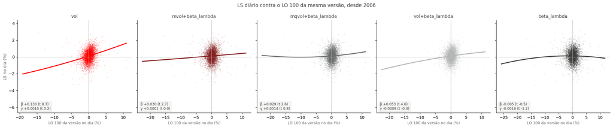

LS contra o LO 100: β, convexidade (γ) e correlação

|  | β | t β | γ | t γ | correlação |
| --- | --- | --- | --- | --- | --- |
| vol | 0.13 | 8.70 | 0.00 | 0.20 | 0.22 |
| mvol+beta_lambda | 0.03 | 2.70 | 0.00 | 0.00 | 0.06 |
| mqvol+beta_lambda | 0.03 | 2.60 | 0.00 | 0.80 | 0.05 |
| vol+beta_lambda | 0.05 | 4.60 | -0.00 | -0.40 | 0.10 |
| beta_lambda | -0.01 | -0.50 | -0.00 | -1.20 | -0.00 |

LS médio (% ao dia) nos 5% piores dias do LO 100 e do IBOV, desde 2006

|  | todos os 5% piores do LO | nos dois (LO e IBOV) | só no LO | só no IBOV | dias em comum % |
| --- | --- | --- | --- | --- | --- |
| vol | -0.24 | -0.09 | -0.45 | 0.37 | 58.55 |
| mvol+beta_lambda | 0.07 | 0.18 | -0.10 | 0.59 | 61.11 |
| mqvol+beta_lambda | 0.07 | 0.17 | -0.09 | 0.60 | 61.11 |
| vol+beta_lambda | -0.00 | 0.10 | -0.16 | 0.54 | 61.54 |
| beta_lambda | 0.18 | 0.27 | 0.03 | 0.67 | 59.83 |

Voltar ao Menu

### **LS contra o IBOV**

Retorno médio do LS por faixa de retorno diário do IBOV, desde 2006, e a dispersão com a curva LS = α + β·IBOV + γ·IBOV². γ negativo seria convexidade vendida (o LS perde nas pontas, dos dois lados).

LS médio (% ao dia) por faixa do IBOV, desde 2006

|  | dias | IBOV médio % | vol | mvol+beta_lambda | mqvol+beta_lambda | vol+beta_lambda | beta_lambda |
| --- | --- | --- | --- | --- | --- | --- | --- |
| < −8% | 10.00 | -11.29 | -0.20 | 0.33 | 0.36 | 0.01 | 0.38 |
| −8 a −6% | 11.00 | -6.97 | 0.56 | 0.69 | 0.59 | 0.65 | 0.70 |
| −6 a −4% | 28.00 | -4.76 | 0.09 | 0.37 | 0.38 | 0.31 | 0.54 |
| −4 a −2% | 295.00 | -2.69 | 0.10 | 0.31 | 0.31 | 0.26 | 0.40 |
| −2 a −1% | 604.00 | -1.40 | 0.13 | 0.24 | 0.25 | 0.21 | 0.28 |
| −1 a 0% | 1569.00 | -0.38 | 0.12 | 0.15 | 0.15 | 0.14 | 0.16 |
| 0 a 1% | 1374.00 | 0.47 | 0.10 | 0.07 | 0.07 | 0.08 | 0.05 |
| 1 a 2% | 685.00 | 1.45 | 0.08 | -0.03 | -0.04 | 0.00 | -0.08 |
| 2 a 4% | 295.00 | 2.62 | 0.01 | -0.18 | -0.18 | -0.12 | -0.24 |
| 4 a 6% | 35.00 | 4.80 | -0.31 | -0.56 | -0.55 | -0.44 | -0.62 |
| 6 a 8% | 10.00 | 7.07 | -0.72 | -0.78 | -0.77 | -0.69 | -0.66 |
| > 8% | 8.00 | 10.91 | -0.69 | -0.78 | -0.67 | -0.74 | -0.79 |

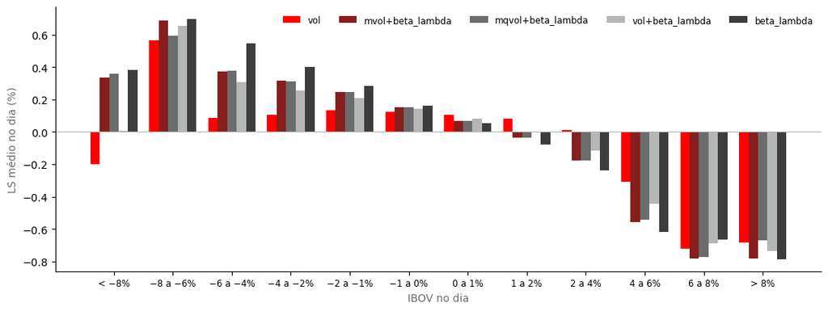

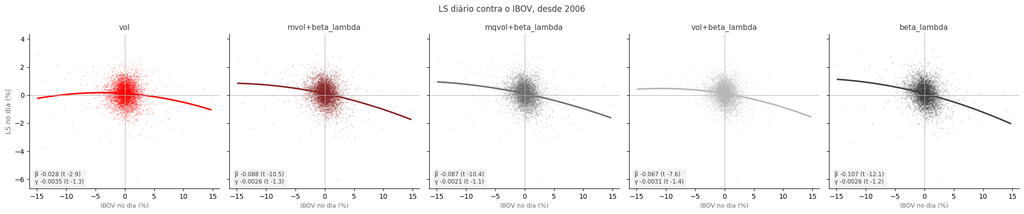

LS contra o IBOV: β, convexidade (γ) e correlação

|  | β | t β | γ | t γ | correlação |
| --- | --- | --- | --- | --- | --- |
| vol | -0.03 | -2.90 | -0.00 | -1.30 | -0.06 |
| mvol+beta_lambda | -0.09 | -10.50 | -0.00 | -1.30 | -0.21 |
| mqvol+beta_lambda | -0.09 | -10.40 | -0.00 | -1.10 | -0.21 |
| vol+beta_lambda | -0.07 | -7.60 | -0.00 | -1.40 | -0.16 |
| beta_lambda | -0.11 | -12.10 | -0.00 | -1.20 | -0.25 |

Voltar ao Menu

### **Alocação e Exposição**

Peso do LS e do LO no Essencial (pesos desempacotados) e o net e o gross do LS (soma dos pesos por papel, em fração do patrimônio do LS). O net é o pedaço de LO embutido no LS: numa crise em que tudo cai junto, ele vira beta antes que o modelo consiga zerá-lo.

Peso do LS e do LO no Essencial (semanal)

[interactive chart not shown]

Net do LS (% do patrimônio do LS, semanal)

[interactive chart not shown]

Alocação e exposição do LS, desde 2006

|  | peso médio do LS no Essencial % | peso médio do LO no Essencial % | gross médio do LS % | net médio do LS % | net p5 % | net p95 % | net mínimo % | net máximo % | dias com \|net\| > 30% (%) | net do LS hoje % |
| --- | --- | --- | --- | --- | --- | --- | --- | --- | --- | --- |
| vol | 71.00 | 23.20 | 201.30 | 30.30 | 0.30 | 63.90 | -3.00 | 74.00 | 48.70 | 2.10 |
| mvol+beta_lambda | 74.10 | 21.50 | 195.20 | 12.60 | -0.00 | 29.30 | -4.70 | 35.40 | 3.80 | 2.40 |
| mqvol+beta_lambda | 74.30 | 21.50 | 194.30 | 12.10 | 0.00 | 29.70 | -5.10 | 37.50 | 4.70 | 2.50 |
| vol+beta_lambda | 74.20 | 21.50 | 194.90 | 15.40 | 0.20 | 32.40 | -4.80 | 39.90 | 9.20 | 2.40 |
| beta_lambda | 73.10 | 19.40 | 194.20 | 0.60 | -2.70 | 4.60 | -8.20 | 11.30 | 0.00 | 0.00 |

Voltar ao Menu

### **Conclusão**

**A fusão `mvol+beta_lambda` deixa o LS muito mais independente do LO, que é o que a decisão buscava.** A correlação do LS com o LO cai de 0,25 para 0,06 e o β do LS ao LO, de 0,18 para 0,04; contra o LO 100, de 0,13 para 0,03. A correlação do alfa com o beta do fundo vai de 0,12 para 0,05. Nos 5% piores dias do LO 100, o LS da `vol` perde −0,24% ao dia; o da fusão ganha +0,07%.

**O que a fusão tira é o LO embutido no LS.** O net do LS cai de 30% em média (p95 de 64%, máximo de 74%, quase metade dos dias acima de 30%) para 13% (p95 de 29%, máximo de 35%). Nos choques de queda, o LS perde −1,5% contra −1,9% da `vol`, e a diferença vem do β surpresa (−0,24% contra −0,70%), não da seleção, que é parecida (−1,8% contra −1,5%). Por faixa do IBOV, a fusão rende mais em todas as quedas (de −4% a −6%, +0,37% ao dia contra +0,09%; abaixo de −8%, +0,33% contra −0,20%).

**O limite:** a fusão não neutraliza os fatores. Nos dias em que o LO cai por fator, e não por mercado (5% piores do LO fora dos 5% piores do IBOV), o LS ainda perde, só que menos: −0,10% ao dia, contra −0,45% da `vol`. Nos choques em que a perda foi de seleção (Covid Circuit Break, Joesley Day), a fusão perde tanto quanto a `vol` ou mais. Esse risco é de alocação, não de neutralização.

**O custo está nas altas fortes, quando o LO ganha.** O LS fica com β de −0,09 ao IBOV (t −10,5), contra −0,03 da `vol`: nos dias de IBOV entre +4% e +6%, rende −0,56% contra −0,31%. Convexidade não há: o γ é negativo nas cinco versões, mas sem significância (t entre −1,1 e −1,4). O LS isolado tem drawdown maior (−16,5% contra −11,3%), com o mesmo Sharpe (1,78 contra 1,81).

**No Essencial, o ganho é de diversificação, não de retorno, e não é significativo.** Desde 2008, Sharpe de 2,12 para 2,21 (t 1,35); em 10 anos, de 2,38 para 2,46; em 5 anos, de 1,54 para 1,72. O max DD não muda (−9,8%). A média dos choques de queda vai de −2,4% para −1,6% e o Lula Day, de −6,7% para −4,8%. Todos os horizontes apontam para o mesmo lado, mas a decisão não se apoia no Sharpe, e sim na independência entre LS e LO.

**Entre as versões:** a `mqvol+beta_lambda` é quase a mesma carteira (correlação de 0,997 com a `mvol+beta_lambda`) e os números ficam dentro do ruído; vale o que a etapa anterior concluiu, a janela importa mais que o método. A `vol+beta_lambda` fica no meio do caminho (β ao LO de 0,08, net de 15%): sem a janela de 12 meses, metade do LO embutido continua. A `beta_lambda` pura é a mais independente (β ao LO de 0,00, net de 1%), mas o LS tem max DD de −19,8% e β de −0,11 ao IBOV: vendida demais em bolsa. A decisão se mantém: **`mvol (2m|12m) + beta_lambda`**, fundidas no passo 10 do Factors.